# Half time

커리큘럼 중간 점검

Author

최요한

Published

Invalid Date

# 1 데이터 분석 및 시각화 중간 점검

## 1.1 교육 과정 개요

- **과정명**: 국제개발협력 실무자를 위한 데이터 분석 및 시각화 과정
- **보고 시점:** 전체 7주차 중 5주차 완료 시점

## 1.2 강의 커리큘럼

주차

내용

시각화 & 데이터

1주차

tidyverse 설치

GUI, CLI 차이점

데이터 분석 시각화(1)

- dataSaurus
- readr

2주차

- 엑셀 파일 연동
- 표 만들기
- 데이터 구조 파악하기
- (공공데이터포탈) KOICA SDGs 연계 현황.xlsx
- palmerpenguins
- ggplolt

3주차

- 데이터 변형
- 요약 통계 정리/확인
- (공공데이터포탈) KOICA 해외봉사단 지원실적.csv
- dplyr

4주차

- 설문조사 설계/분석
- 중심극한정리
- 중간 퀴즈(15문제)
- penguins
- 🔗 [표본 시뮬레이션](https://onlinestatbook.com/stat_sim/sampling_dist/index.html)
- 게스트 스터디 경험 공유 (w. 김규동님)

5주차

- t-검정
- 긴형식/넓은 형식
- 펭귄의 체중 비교
- penguins
- sleep
- treemap

6주차

- KOICA 2023년도 예산 집행 내역
- 에티오피아 손씻기 임팩트 평가(1)
- 기대수명과 GDP 관계
- CLTSH
- gapminder
- KOICA 2023년도 예산 집행 내역.xlsx

7주차

- KOICA 2024년도 예산 집행 내역
- 에티오피아 손씻기 임팩트 평가(2)
- CLTSH
- KOICA 2024년도 예산 집행 내역.xlsx
- 1인당 5분 발표 프로젝트수행

# 2 1~5주차 교육 회고

## 2.1 **국제개발협력 공공데이터 활용 분석 (1~3주차)**

- 엑셀(GUI)와 R(CLI)환경의 차이점
- RStudio 환경에서 `tidyverse` 패키지를 활용한 데이터 전처리 학습
- KOICA 사업별 SDGs 연계 현황 및 해외봉사단 파견 현황 데이터 분석

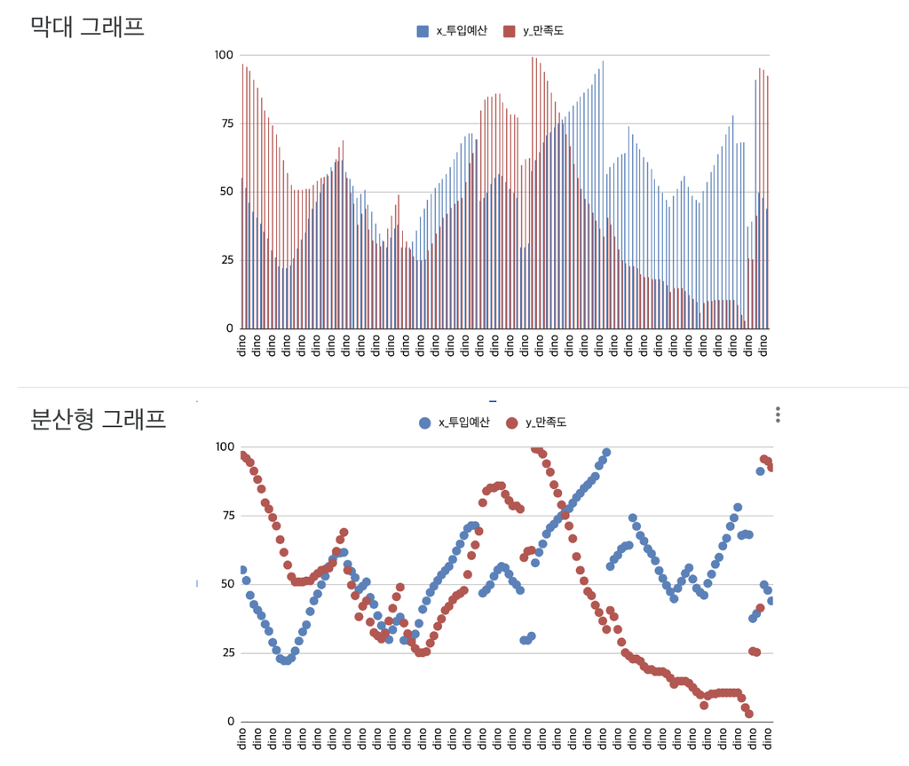

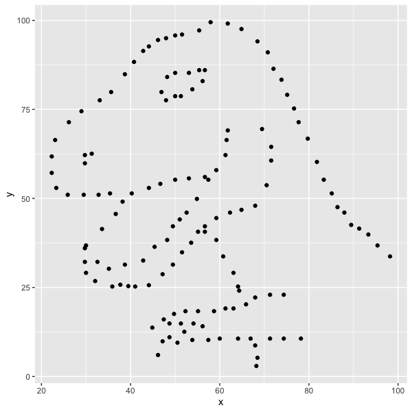

## 2.2 탐색적 데이터 분석(EDA) 및 통계 기초 학습 (4주차)

- PalmerPenguins 데이터를 활용한 단변량·다변량 변수의 관계 해석
- 시뮬레이션을 통한 ‘큰 수의 법칙’ 및 ’중심극한정리’의 시각적 이해
- 단순 취합용 설문을 넘어, 즉각적인 통계 분석이 가능하도록 설문 설계 능력 습득

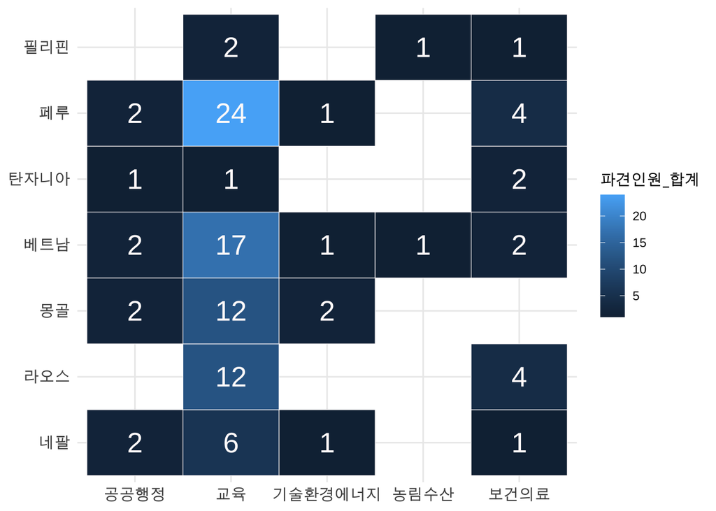

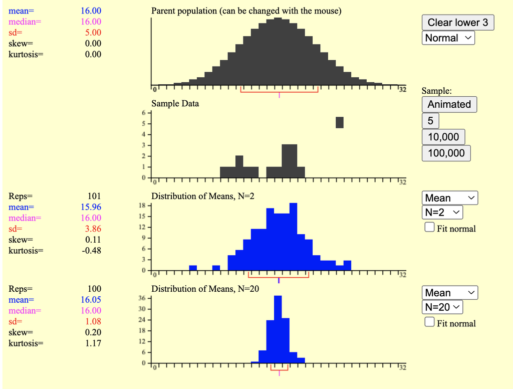

## 2.3 데이터 기반의 가설 검정 및 비교 (5주차)

- t-test 등 두 그룹 간의 데이터에 대한 통계적 비교 기법 학습
- 제리백 가방 판매 데이터 분석

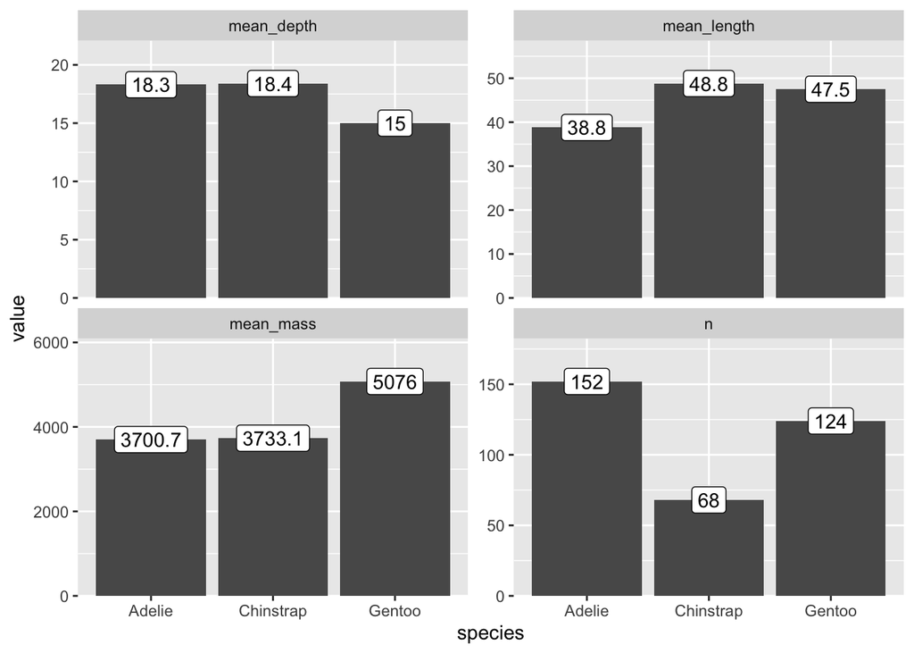

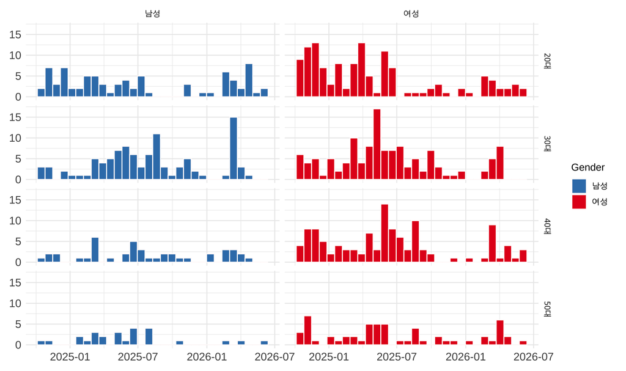

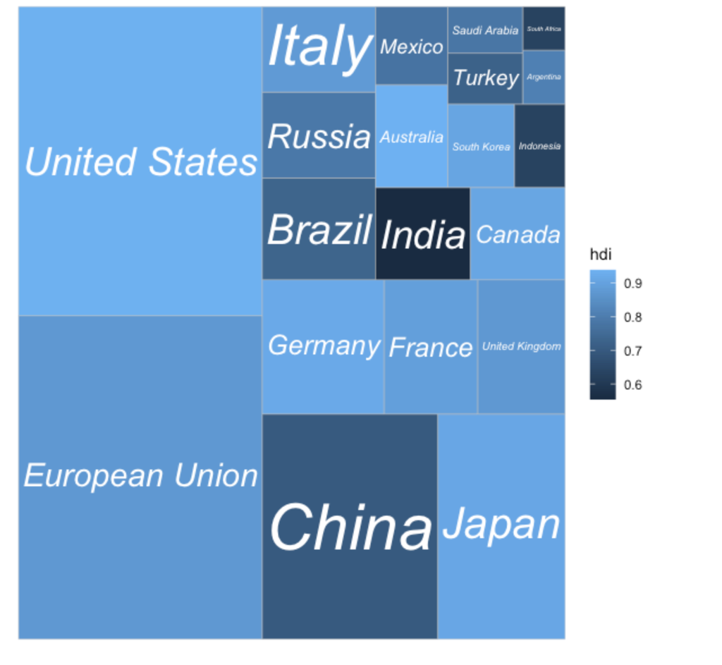

# 3 **6~7주차 교육 계획**

## 3.1 **6주차**

- KOICA 2023년도 예산 집행 내역 분석
- 에티오피아 손씻기 임팩트 평가(1) 탐색적 데이터 분석

## 3.2 **7주차 계획**

- 에티오피아 손씻기 임팩트 평가(2) 발표 (1인당 5분)
- 최종 성과 공유회를 통한 데이터 중심의 토론과 발표

# 4 강사 소회

> 현재 수강생 전원이 기본적인 코딩 능력을 보여주며, 매주 제출되는 과제의 완성도가 기대 이상으로 높음

> 남은 2주간 현업의 Real data를 활용하여 수강생들이 조직 내에서 데이터 기반 성과 관리를 주도할수 있도록 교육에 최선을 다하고자 함

> 본 과정을 수료한 수강생들은 사업 성과 분석(M&E) 뿐만 아니라 모금 및 후원자 유형 분석, 기부자 생애 가치(LTV)와 같은 퍼널 분석을 할 수 있는 기본 역량을 갖추었다고 할수 있음

끝.